# final

[figure not shown]

```python
from IPython.display import HTML
HTML('''<script>
code_show=true;
function code_toggle() {
if (code_show){
$('div.input').hide();
} else {
$('div.input').show();
}
code_show = !code_show
}
$( document ).ready(code_toggle);
</script>
<form action="javascript:code_toggle()"><input type="submit" value="Click here to toggle on/off the raw code."></form>''')
```

*Idan Keipour 315355537*

*Menachem Sokolik 314696972*

*Maria Mordvova 345232821*

## *Election Dataset - Analysis and Methods for "Yahadut HaTora".*

```python
import numpy as np  # a module for working with numerical array
import pandas as pd  # a module for working with data-frames
import io
import statsmodels.formula.api as sm
import statsmodels.api as sm
import matplotlib.pyplot as plt
from matplotlib.pyplot import figure
from sklearn.decomposition import PCA
from sklearn import preprocessing
import matplotlib.lines as mlines
import scipy as sy
import plotly.graph_objects as go
from sklearn.preprocessing import normalize
import seaborn as sn
```

```python
# Add a check if we run in google colab or locally in jupyter notebook
run_in_colab = False
if 'google.colab' in str(get_ipython()):
    run_in_colab = True
    print('Running on CoLab')
else:
    print('Running locally on Jupyter')

# Mount drive in google colab
if run_in_colab:
    from google.colab import drive
    drive.mount('/content/drive')
else:  # Set local path
    data_path = "C:/Users/menac/OneDrive/Desktop/52568 STATISTICS LAB/LAB2"
```

```
Running on CoLab
```

```python
# Loading elections 2020 and 2021 data - ballot and cities:
if run_in_colab:
    from google.colab import files
    uploaded = files.upload()
```

Upload widget is only available when the cell has been executed in the current browser session. Please rerun this cell to enable.

```
Saving eshkol_hevrati_calcali.csv to eshkol_hevrati_calcali.csv
Saving eshkol_hevrati_calcali.xlsx to eshkol_hevrati_calcali.xlsx
Saving votes per ballot 2020.csv to votes per ballot 2020.csv
Saving votes per ballot 2021.csv to votes per ballot 2021.csv
Saving votes per city 2020.csv to votes per city 2020.csv
Saving votes per city 2021.csv to votes per city 2021.csv
```

```python
parties_dict_2021 ={'אמת' : "עבודה", 'מרצ' : "מרצ",  'ג' : "יהדות התורה", 'עם'  : "רעם",  'ת'  : "תקוה חדשה", 'ודעם'  : "הרשימה המשותפת", 'ב'  : "ימינה"
     , 'ט'  : "הציונות הדתית",'ל'  : "ישראל ביתנו", 'מחל'  : "הליכוד",  'פה'  : "יש עתיד", 'כן'  : "כחול לבן", 'שס'  : "שס"}

parties_dict_2020 ={'אמת' : "עבודה גשר מרצ", 'ג' : "יהדות התורה", 'ודעם'  : "הרשימה המשותפת"
    , 'טב'  : "ימינה", 'נץ'  : "עוצמה יהודית", 'ל'  : "ישראל ביתנו", 'מחל'  : "הליכוד",  'פה'  : "כחול לבן", 'שס'  : "שס"}

df_2021_raw = pd.read_csv(io.BytesIO(uploaded['votes per city 2021.csv']),  encoding = 'iso-8859-8', index_col='שם ישוב')
df_2020_raw = pd.read_csv(io.BytesIO(uploaded['votes per city 2020.csv']),  encoding = 'iso-8859-8', index_col='שם ישוב')

# preprocessing of cities
df_2021_raw.rename(columns=parties_dict_2021, inplace=True)
df_2021_raw = df_2021_raw[df_2021_raw.columns[:-1]]
df_2021 = df_2021_raw.drop('סמל ועדה', axis=1) # new column added in 2020
df_2021 = df_2021[df_2021.columns[5:]] # removing "metadata" columns

df_2020_raw.rename(columns=parties_dict_2020, inplace=True)
df_2020_raw = df_2020_raw[df_2020_raw.columns[:-1]]
df_2020_raw =  df_2020_raw.drop('מעטפות חיצוניות')
df_2020 = df_2020_raw.drop('סמל ועדה', axis=1) # new column added in 2020
df_2020 = df_2020[df_2020.columns[5:]] # removing "metadata" columns
# Dataset is now stored in a Pandas Dataframe

df_2021_ballots_raw = pd.read_csv(io.BytesIO(uploaded['votes per ballot 2021.csv']),  encoding = 'iso-8859-8', index_col='שם ישוב').sort_index()
df_2021_ballots_raw = df_2021_ballots_raw.drop('סמל ועדה', axis=1) # new column added in 2021
df_2021_ballots_raw =  df_2021_ballots_raw.drop('מעטפות חיצוניות')
df_2021_ballots = df_2021_ballots_raw[df_2021_ballots_raw.columns[:-1]]
df_2021_ballots = df_2021_ballots[df_2021_ballots.columns[9:]] # removing "metadata" columns
df_2021_ballots.rename(columns=parties_dict_2021, inplace=True)

df_2020_ballots_raw = pd.read_csv(io.BytesIO(uploaded['votes per ballot 2020.csv']),  encoding = 'iso-8859-8', index_col='שם ישוב').sort_index()
df_2020_ballots_raw = df_2020_ballots_raw[df_2020_ballots_raw.columns[:-1]]
df_2020_ballots_raw = df_2020_ballots_raw.drop('סמל ועדה', axis=1) # new column added in 2020
df_2020_ballots_raw =  df_2020_ballots_raw.drop('מעטפות חיצוניות')
df_2020_ballots_raw.rename(columns=parties_dict_2020, inplace=True)
```

```python
# Compute votes share only for parties above a certain threshold
def parties_votes_percents(df, thresh):
    par = df.sum().div(df.sum().sum()).sort_values(ascending=False)
    return par[par > thresh]

votes = parties_votes_percents(df_2021, 0.035)  # total votes for each party
names = votes.keys()
```

### *Background*

*United Torah Judaism (Hebrew: יהדות התורה, Yahadut HaTora), often referred to by its electoral symbol Gimel (ג), is a religious conservative political alliance in Israel. The alliance, consisting of Agudat Yisrael and Degel HaTorah, was first formed in 1992, in order to maximize Ashkenazi Haredi representation in the Knesset. Despite the alliance splitting in 2004 over rabbinical differences, the parties reconciled in 2006, in order to prevent vote wasting. In April 2019, the party achieved its highest number of seats ever, receiving eight seats. Unlike similar religiously-oriented parties like Shas, The Jewish Home, Tkuma, and Noam, UTJ is non-Zionist. However, unlike some other Haredim, the party is notable for its usage of technology and electronic communication.*

*For a party no political change was made between the two elections.*

*The party remained as it is without unification or separation from other parties. She ran in both elections when she addressed the same electorate with a change of chairmen at her head.*

### *A.*

*The elections to the 24th Knesset marked a deep line in the Israeli political system. For the first time ever, and unusually also in relation For other democracies in the world, four elections were held in Israel in a very short time. The reason for this abnormal phenomenon lies in the fact that That the previous three incomes have failed to form a government.*

*In this report,we will analyze the "Yahadut HaTora" Party in the 2020 and 2021 elections and present a statistical analysis of its results and comparisons between them.*

*To write the report, we used the following files:*

- Voting data by polling station, voting data by locality (over election dates) - We used columns attributions to the voting data (for each party, kosher, bzb, invalid, name of town)
- Ranking of localities by socio-economic cluster - We used the ranking to characterize the voters. Ranking of localities by level of peripherality - as above.
- Division of localities into districts - as above.

*To prepare the data, we took the following steps:*

- Downloading outer envelopes - Apart from the first item of the percentage of votes for the Torah Judaism Party, we decided to download The outer envelopes from the whole data for a number of reasons: they contain a vote of different and diverse populations and on Yes It is not correct to draw on the basis of indicative statistics (such as specific characteristics). Also, their bzb is zero, so some of the surgeries will not be feasible, as in correcting the votes by weighting. They are not suspicious ballots because Which incorporates votes from the general population and not by location or city. In addition to these, the percentage of votes for the Judaism Party The Torah from "outer envelope" ballots is negligible in its effect as and therefore can be removed to prevent distortion The surgery.
- We turned the index of the polling station data according to the locality symbol and the polling symbol to the numbering of the polling station.
- Reverse the index of the locality data by locality name.
- We have created dictionaries to translate the letters of the parties to their names for clear presentation.

### *B. Explain how the party has changed in the 2 election campaigns: from the 2020 election to the election 2021*

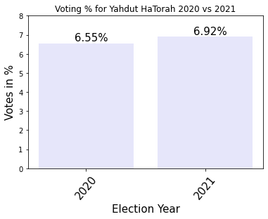

```
(<Figure size 432x288 with 1 Axes>,
```

```python
freq_2020 = df_2020_raw.iloc[:,1].sum()/df_2020_raw.iloc[:,7].sum()
freq_2021 = df_2021_raw.iloc[:,1].sum()/df_2021_raw.iloc[:,8].sum()
freq_lst = [freq_2020,freq_2021]


def changes(value, title):
    width = 0.2  # set column width
    names = ['2020', '2021']

    fig, ax = plt.subplots()

    n1 = len(value)
    bar_plt = ax.bar(np.arange(n1), value, color='lavender')

    ax.set_ylabel('Votes in %', size = 15)
    plt.ylim(0,8)
    ax.text(-0.1,6.7,str(round(value[0],2))+"%",size=15)
    ax.text(0.9,7,str(round(value[1],2))+"%",size=15)
    ax.set_xlabel('Election Year', size = 15)
    ax.set_xticks(np.arange(n1))
    ax.set_xticklabels(names, rotation=50, size= 15)
    ax.set_title(title)

    plt.show()

    return fig, ax


changes(freq_lst, title = "Voting % for Yahdut HaTorah 2020 vs 2021" )
```

It can be clearly seen that the % of votes has stayed almost at the same level during 2020 to 2021. Consiquently,there is not a big change. However, we know that 9 biggest parties of 2020 in 2021 have splitted in 13 parties. Therefore, it also might have affected the distribution of the votes among the parties, it can be the reason for the slight rise of % in 2021. Another reason, for this slight rise among voters in preference for Yahdud HaTorah can be that in 2021 Moshe Gafni became the head of the party insread of Ya'akov Litzman.

### *c. Show how the turnout of the game affected the vote for the party.*

```python
v = df_2021_raw['כשרים'].div(df_2021_raw['בזב'])
df_fix = df_2021.div(v , axis = 'rows')
```

To begin with,we are interested in examining what the election results would have been if all people that have a right to vote would have voted. We assume that in every settlement/city the distribution of votes among eligible voters the choice that they did not vote or that their votes were invalid is the same as the distribution of votes of the kosher votes in the same locality. Nevertheless, in each locality the distribution may be different.

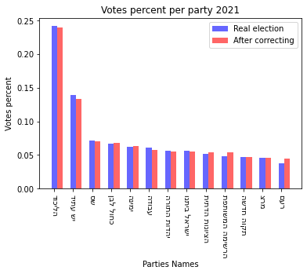

```
(<Figure size 432x288 with 1 Axes>,
```

```python
def party_bar_fix(df1, df2, thresh):
    width = 0.3  # set column width
    votes = parties_votes_percents(df1, thresh)  # total votes for each party
    n = len(votes)  # number of parties
    names = votes.keys()

    fixed_votes = parties_votes_percents(df2, thresh)

    rev_names = [name[::-1] for name in list(names)]
    fig, ax = plt.subplots()  # plt.subplots()

    all_bar = ax.bar(np.arange(n), list(votes), width, color='b',alpha=0.6)
    fix_bar = ax.bar(np.arange(n)+width, list(fixed_votes), width, color='r',alpha=0.6)

    ax.set_ylabel('Votes percent')
    ax.set_xlabel('Parties Names')
    ax.set_title('Votes percent per party 2021')
    ax.set_xticks(np.arange(n))
    ax.set_xticklabels(rev_names,rotation=-90)
    ax.legend((all_bar[0], fix_bar[0]), ('Real election', 'After correcting'))
    plt.show()

    return fig, ax

def gimel_copmare(df1, df2, thresh):
  width = 0.2  # set column width
  votes = parties_votes_percents(df1, thresh)  # total votes for each party
  gimel_real = votes['יהדות התורה']
  n = 1
  fixed_votes = parties_votes_percents(df2, thresh)
  gimel_fix = fixed_votes['יהדות התורה']
  fig, ax = plt.subplots()  # plt.subplots()
  all_bar = ax.bar(np.arange(n), gimel_real, width, color='b',alpha=0.6)
  fix_bar = ax.bar(np.arange(n)+width*1.2, gimel_fix, width, color='r',alpha=0.6)
  ax.set_ylabel('Votes percent')
  plt.ylim(0,0.09)
  ax.set_title('Resoults for "Yahadut Hatora"')
  ax.set_xticks(np.arange(n))
  ax.legend((all_bar[0], fix_bar[0]), ('Real election', 'After correcting'))
  ax.text(-0.03,0.059,str(round(gimel_real*100,3))+"%",size=14)
  ax.text(0.2,0.055,str(round(gimel_fix*100,3))+"%",size=14)
  plt.tick_params(
    axis='x',
    which='both',
    bottom=False,
    top=False,
    labelbottom=False)
  plt.show()

  return fig, ax

party_bar_fix(df_2021, df_fix, 0.035)
```

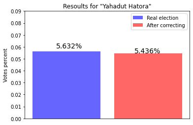

```
(<Figure size 432x288 with 1 Axes>,
```

```python
gimel_copmare(df_2021, df_fix, 0.035)
```

From the above plots it can be clearly seen that the correction has decreased the percentage of votes for the Torah Judaism Party . Therefore, it can be concluded that in relation to the other parties, the percentage of Torah Judaism voting among the potential voters is high.

Consequently, we would like to test this assumption. To do so, we consider the ratio between the actual total number of voters for Torah Judaism and the total number of potential voters according to the correction. After that, we will compare this ratio to the overall actual turnout:

```python
vote_percent = round(df_2021['יהדות התורה'].sum()/df_fix['יהדות התורה'].sum(),3)
print('אחוז ההצבעה המשוער בקרב הבוחרים הפוטנציאליים של מפלגת יהדות התורה הוא: ' , vote_percent)
total_votes_percent = round(df_2021_raw['מצביעים'].sum()/df_2021_raw['בזב'].sum(),3)
print('אחוז ההצבעה הכללי על פי תוצאוות האמת הוא: ' , total_votes_percent)
```

```
אחוז ההצבעה המשוער בקרב הבוחרים הפוטנציאליים של מפלגת יהדות התורה הוא:  0.695
אחוז ההצבעה הכללי על פי תוצאוות האמת הוא:  0.674
```

It can be clearly seen that the % of potentional voters for Torah Judaism is higher that the % of total votes.

Th next step, we will now examine whether the election results will be the same when we make the correction to each of the polls (i.e. we assume that all ballots among eligible voters who did not vote or whose votes were invalid are the same as the distribution of eligible votes in that ballot).

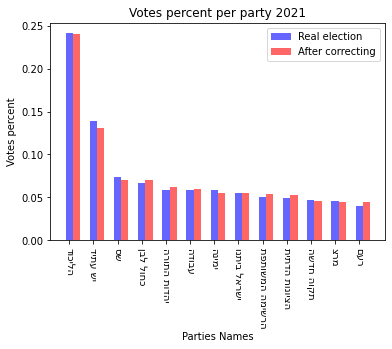

```
(<Figure size 432x288 with 1 Axes>,
```

```python
v = df_2021_ballots_raw['כשרים'].div(df_2021_ballots_raw['בזב'])
df_fix_b = df_2021_ballots.div(v, axis = "rows")

party_bar_fix(df_2021_ballots, df_fix_b, 0.035)
```

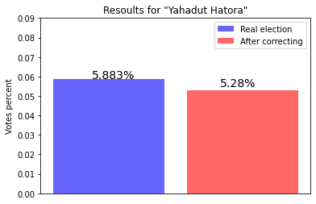

```
(<Figure size 432x288 with 1 Axes>,
```

```python
gimel_copmare(df_2021_ballots, df_fix_b, 0.035)
```

Indeed, when the correction is made for all the ballots of the Torah Judaism Party, we can see that it decrease the vote %.

```python
df_city_clean = df_2021.drop('מעטפות חיצוניות')
total_votes = parties_votes_percents(df_2021, 0.035)  # total votes for each party
names = total_votes.keys() # 13 parties
df_city_clean = df_city_clean[names]
df_city_freq = df_city_clean.div(df_city_clean.sum(axis=1) , axis = 'rows') #בכל עיר ישנו אחוז ההצבעה בעיר לכל מפלגה
```

### *D. Show how the frequency of voting for the party varies between different localities and polling stations.*

Furthermore, we are interested in examining what are the party's main polling stations.To do this we would like to look at the city file and not the polling file because the ultra-Orthodox population is characterized by living in nearby areas, so even though there may be polling stations where the party's main polling station is located but in a neighborhood (or a relatively limited geographical area) inhabited mainly by ultra Orthodox residents.

```python
h_citys = df_city_freq.nlargest(10,"יהדות התורה")['יהדות התורה'].to_frame()
h_citys = h_citys.set_axis(["אחוז התושבים שמצביעים ביישוב למפלגת יהדות התורה"],axis=1)
h_citys
```

| שם ישוב | אחוז התושבים שמצביעים ביישוב למפלגת יהדות התורה |
| --- | --- |
| קוממיות | 0.941935 |
| בית חלקיה | 0.884615 |
| יסודות | 0.877814 |
| מודיעין עילית | 0.793303 |
| מתתיהו | 0.777457 |
| תפרח | 0.740068 |
| קרית יערים | 0.677143 |
| בני ברק | 0.609030 |
| ביתר עילית | 0.603616 |
| מעלה עמוס | 0.535211 |

The table above shows the localities in which the percentage of votes for the Torah Judaism Party is the highest. As expected, it can be seen that these are ultra-Orthodox localities. In addition, most of them are relatively small localities, which explains big homogeneity in the turnout.

We will now examine the localities in which the percentage of votes for the Torah Judaism Party is the lowest:

```python
l_citys = df_city_freq.nsmallest(10,"יהדות התורה")['יהדות התורה'].to_frame()
l_citys = l_citys.set_axis(["אחוז התושבים שמצביעים ביישוב למפלגת יהדות התורה"],axis=1)
dff = df_city_freq[(df_city_freq['יהדות התורה']==0)] # a DF with all the places where no one vote to yahadut hatora
l_citys
```

| שם ישוב | אחוז התושבים שמצביעים ביישוב למפלגת יהדות התורה |
| --- | --- |
| אבירים | 0.0 |
| אושה | 0.0 |
| אחווה | 0.0 |
| איבים | 0.0 |
| אלעריאן | 0.0 |
| אלוני יצחק | 0.0 |
| אליעד | 0.0 |
| אלמגור | 0.0 |
| אמציה | 0.0 |
| אפיק | 0.0 |

From the above table we can conclude that the localities in which there was no vote at all for the Torah Judaism Party are localities characterized mainly as agricultural, kibbutzim or Arab localities. We need to note, that there are 584 such localities where the turnout was the lowest and the above 10 localities are just a sample of them.

**Socio-Economic Analysis**

We will now examine the socio-economic cluster of the voters of the Torah Judaism Party.

There is a division of localities according to a socio-economic cluster, with each locality being ranked in a number between 1 and 10. The meaning of the ranking is that locality that received 1 is in the lowest socio-economic cluster while locality that received the rating 10 is in the highest socio-economic situation.

At this stage, we performed two analyzes - one examining the percentage of votes for the Torah Judaism Party in each cluster and the other one is examining the percentages of Torah Judaism's voting by clusters.

```python
if   run_in_colab:
      df_eshkol_hevrati_raw = pd.read_excel(io.BytesIO(uploaded['eshkol_hevrati_calcali.xlsx']), index_col='name')
else:
  df_eshkol_hevrati_raw = pd.read_excel(data_path + 'eshkol_hevrati_calcali.xlsx',  index_col='name')  # need to read locally

#Joining the dataframes
merged_df = df_city_clean
merged_df['סמל ישוב'] = df_2021_raw['סמל ישוב']
merged_df = merged_df.join(df_eshkol_hevrati_raw.set_index('set_code'), on='סמל ישוב') #joining the dataframes by the set code column
merged_df = merged_df.dropna()
```

```python
dataF =  pd.DataFrame()
for i in range(1, 11):
    # np.where we find the eco level
    cities = np.where(merged_df['eco_level'].values.astype('float') == i)[0]
    dataF[i] = merged_df.iloc[cities][names].sum().div(merged_df.iloc[cities][names].sum().sum())
dataF = dataF.T
```

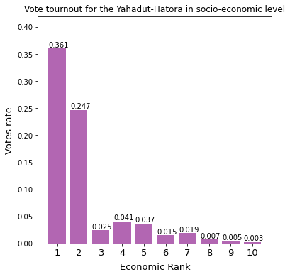

```python
#Choose only יהודת התורה party
p_df_jt = dataF[dataF.columns[6]]
p_df_jt = pd.DataFrame(p_df_jt)
df_tran_jt = p_df_jt.T
eco_rank1 = np.arange(1, 11, 1).tolist()
y_e = round(df_tran_jt.iloc[0,:],3)

figure(figsize=(8,8))
plt.title("Vote tournout for the Yahadut-Hatora in socio-economic level",fontsize=12)
plt.ylabel("Votes rate", fontsize = 13)
plt.xlabel("Economic Rank",labelpad=7,fontsize=13)
plt.ylim(0,0.42)
plt.xticks(eco_rank1,fontsize=13)
plt.bar(eco_rank1,y_e,color="purple",alpha=0.6)
plt.tight_layout(pad=10)

for index, value in enumerate(y_e):
    plt.text(index+0.6, value + 0.002, str(value))
```

From this graph we see how many of each of the socio-economic rankings voted for the Torah Judaism Party. It can be seen that about 36% of votes the people in the lowest socio-economic cluster - 1 voted for the Torah Judaism Party. Similarly about 25% of the people in the 2 socio-economic cluster voted for this party. In addition, we see that for the higher rankings the turnout for the Torah Judaism Party is low.

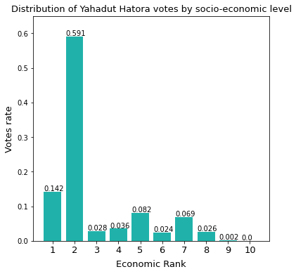

```python
eco_city_parties= merged_df
eco_city_parties['eco_total'] = 0
eco_prop = [0]*10
for i in range(10):
  eco_city_parties['eco_total']= eco_city_parties.loc[eco_city_parties.loc[:,'eco_level']==i+1,['יהדות התורה']].sum(axis=1)
  eco_prop[i] = eco_city_parties['eco_total'].sum()
eco_prop = eco_prop/(merged_df.loc[:,'יהדות התורה'].sum())

figure(figsize=(8,8))
plt.title("Distribution of Yahadut Hatora votes by socio-economic level",fontsize=13)
plt.ylabel("Votes rate", fontsize = 13)
plt.xlabel("Economic Rank",labelpad=7,fontsize=13)
plt.ylim(0,0.65)
plt.xticks(eco_rank1,rotation=0,fontsize=13)
plt.bar(eco_rank1,eco_prop,color="lightseagreen")
plt.tight_layout(pad=10)

for index, value in enumerate(eco_prop):
    plt.text(index+0.6, value+0.002, str(round(value,3)))
```

Comparing to the previous graph where we see what percentage of the votes voted for Torah Judaism in each of the socio-economic ranks, in this graph we see from which ranks most of the party's votes came. We see that almost 60% (main suppoerts group) come from 2nd socio-economic cluster. Furthemore, about 14% of the votes came from the 1st socio-economic cluster. Also we see that Torah Judaism Party almost does not have supporters from the highest socio-economic clusters. That is, we can make a conclustion that most of the voters for Torah Judaism come from the lowest socio-economic clusters.

**Support for the Party according to size of the city**

We would now like to examine whether support for the Torah Judaism Party varies depending on the size of the city. The size of the city was calculated according to the number of eligible voters in the city while the percentage of voters for the party was calculated in relation to the parties that passed the blocking percentage only.

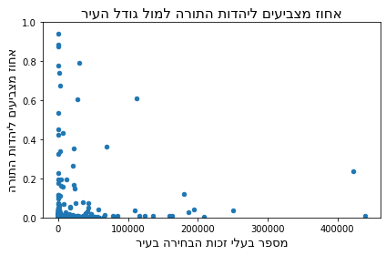

```python
size = df_2021_raw.drop('מעטפות חיצוניות')['בזב']
gimel_freq = df_city_freq['יהדות התורה']

plt.scatter(size,gimel_freq,s=20)
plt.ylim(0,1)
plt.xlabel('מספר בעלי זכות הבחירה בעיר'[::-1] , fontsize=13)
plt.ylabel('אחוז מצביעים ליהדות התורה'[::-1] , fontsize=13)
plt.title('אחוז מצביעים ליהדות התורה למול גודל העיר'[::-1] ,fontsize=15)
plt.tight_layout()
```

We see that there is no clear correlation between the size of the city and the percentage of party support. Most localities have a small number of eligible voters and the percentage of party support ranges along the scale, meaning that there are localities where the turnout for Torah Judaism is high and there are such localities where the turnout is low.

### *E. Presentation of the vote for the Yahadut Hatora Party in all ballots in the form of a presentation by PCA:*

*In this section we will represent at the level unfolded by the first two PCA components the 2021 election ballots for all parties.*** **The size of the circles in the plot, we made according to the percentage of votes for the Yahadut Hatora Party in each ballot box - the larger the circle, the higher the percentage the vote is higher. We will provide that we have normalized the according to the performance of the PCA so that all the ballots in the table are summed to one, so that the analysis be more informative (for all three graphs).

##### *The meaning of the axes:*

*PCA one - characterize this axis as a symbol of nationality: low values - Jewish nationality, high values of Arab nationality.*

*PCA two - Divides the Axis by Religious-Political Ideology: High Values - Ideology of the Left, Low Values - Ideology of the right.*

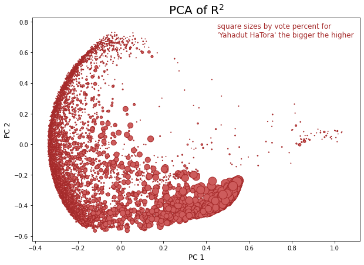

```python
data_pca = df_2021_ballots
normalized_data = normalize(data_pca.T, axis=0) # normalize the data

our_pca = PCA(n_components=2)
x_pca = our_pca.fit_transform(normalized_data.T)  # creating the B base (in R^9)
relevant_components = [x_pca[:,0],x_pca[:,1]]

area = df_2021_ballots_raw['ג']/(df_2021_ballots_raw['כשרים'])*300

#plot for the pca:
plt.figure(figsize=(10,7))
plt.title('PCA of R$^2$', fontsize=20)
plt.xlabel('PC 1', fontsize=12)
plt.ylabel('PC 2', fontsize=12)
plt.text(0.45,0.7,"square sizes by vote percent for" "\n" "'Yahadut HaTora' the bigger the higher",
         size=12, color = "brown")
plt.scatter(relevant_components[0], relevant_components[1], s= area,
            edgecolors="brown",c="indianred")
```

- *I will note that the following graph was performed on the basis of only the common ballots, then the difference in the graphs is due to the fact that the number of dimensions of the matrix is smaller than the previous one.*

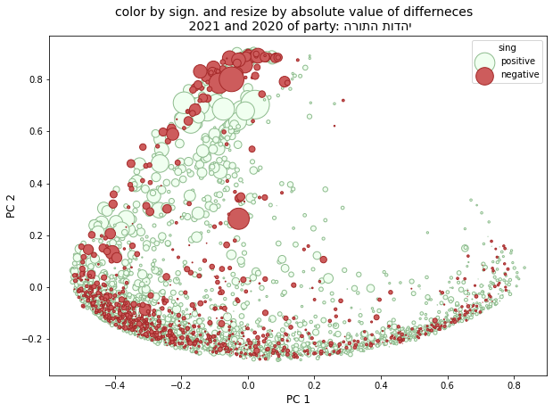

```python
df_2020_ballot = df_2020_ballots_raw.reset_index()
df_2021_ballot = df_2021_ballots_raw.reset_index()
ballot_match = df_2020_ballot.set_index(['קלפי', 'סמל ישוב','שם ישוב']).join(df_2021_ballot.set_index(['קלפי', 'סמל ישוב','שם ישוב']), lsuffix = '-2020' , how='inner')

ballot_2021 = ballot_match[ballot_match.columns[len(df_2020_ballot.columns)-3:]]
ballot_2020 = ballot_match[ballot_match.columns[0:len(df_2020_ballot.columns)-3]]
ballot_2020.columns = df_2020_ballot.set_index(['קלפי', 'סמל ישוב','שם ישוב']).columns

prop_2021 = pd.DataFrame(ballot_2021['ג']/ballot_2021['כשרים']) # 2021
prop_2020 = pd.DataFrame(ballot_2020['יהדות התורה']/ballot_2020['כשרים']) # 2020

merge_df = prop_2020.join(prop_2021, lsuffix=" 2021",rsuffix=" 2020", how='inner') # merge the data of prop

diff = pd.DataFrame(merge_df.iloc[:,0] - merge_df.iloc[:,1])

data_pca_2020 = ballot_2021[ballot_2021.columns[7:]].join(diff, lsuffix=" 2020",rsuffix=" diff", how='inner')
data_pca_2020 = data_pca_2020.iloc[:,0:39]
data_pca_2020 = normalize(data_pca_2020.T, axis=0)
our_pca2 = PCA(n_components=2)
x_pca2 = our_pca2.fit_transform(data_pca_2020.T)  # creating the B base (in R^9)
relevant_components2 = [x_pca2[:,0],x_pca2[:,1]]

# divide to 2 graphs- positive and negative + reisze the difference by mult by 2000
positive_cpa1, positive_cpa2, negative_cpa1, negative_cpa2, diff_pos, diff_neg =[], [], [], [], [], []

for i in range(len(diff)):
  if diff.iloc[i,0]<0:
    negative_cpa1.append(relevant_components2[0][i])
    negative_cpa2.append(relevant_components2[1][i])
    diff_neg.append(abs(diff.iloc[i,0])*2000)
  elif diff.iloc[i,0]>0:
    positive_cpa1.append(relevant_components2[0][i])
    positive_cpa2.append(relevant_components2[1][i])
    diff_pos.append(diff.iloc[i,0]*2000)
  else: ### dont show pts with 0
    pass

#creating the plot:
figure(figsize=(10,7))
plt.title("color by sign. and resize by absolute value of differneces  \n 2021 and 2020 of party: " + "יהדות התורה"[::-1], fontsize=14)
plt.xlabel('PC 1', fontsize=12)
plt.ylabel('PC 2', fontsize=12)
plt.scatter(positive_cpa1, positive_cpa2, s= diff_pos,
            edgecolors="darkseagreen",c="honeydew")
plt.scatter(negative_cpa1, negative_cpa2, s= diff_neg,
            edgecolors="brown",c="indianred")
plt.legend(labels=["positive","negative"],title = "sing")
plt.show()
```

*In conclusion, we have seen that the majority of votes for Torah Judaism come from polling stations characterized by right-wing religious and political ideology and that According to the observed trend, there is no significant difference between the election campaigns from 2020, to 2021. As we have noted, this figure is consistent with the fact that we saw the differences in the turnout between the two election campaigns and found that indeed the change in the turnout between them was minimal.*

### *F. Present the transition of votes of party voters in previous elections to other parties in elections 2021 (including those who did not vote in 2021) To which parties did the most voters move The party in the previous election:*

*Note: According to the refinement of the question, there was confusion between what was required in sections F, G and H. These sections (F, G) were not included in the "non-voters" but were indeed included in section H. Or zuk approved this replacement as it was included in section H (thus making it easier for us to change the sections - thank you). It may be noted that his questions were explained at length.*

Firstly, we will consider the transition matrix and make a heat map , according to which it will be possible to see the votes transition of the Torah Judaism Party for the 2021 elections.

```python
# dicts that are matched to the elections:
parties_dict_2020_for_f ={'מחל 2020':'הליכוד','פה 2020':'כחול לבן','ודעם 2020':'הרשימה המשותפת','שס 2020':'שס','ג 2020':'יהדות התורה',
              'אמת 2020':'העבודה גשר מרצ','ל 2020':'ישראל ביתנו','טב':'ימינה', 'נץ':'עוצמה יהודית',"לא הצביעו":"לא הצביעו"}

parties_dict_2021_for_f ={'אמת 2021' : "עבודה", 'מרצ' : "מרצ",  'ג 2021': "יהדות התורה", 'עם'  : "רעם",  'ת'  : "תקוה חדשה", 'ודעם 2021'  : "הרשימה המשותפת", 'ב'  : "ימינה"
     , 'ט'  : "הציונות הדתית",'ל 2021'  : "ישראל ביתנו", 'מחל 2021'  : "הליכוד",  'פה 2021'  : "יש עתיד", 'כן'  : "כחול לבן", 'שס 2021'  : "שס" ,"לא הצביעו": "לא הצביעו"}

parties_dict_2021_f ={'עבודה גשר מרצ' : "אמת", 'מרצ' : "מרצ",  'יהדות התורה' : "ג", 'רעם'  : "עם",  'תקוה חדשה'  : "ת", 'הרשימה המשותפת'  : "ודעם", 'ימינה'  : "טב"
     , 'הציונות הדתית'  : "ט",'ישראל ביתנו'  : "ל", 'הליכוד'  : "מחל",  'כחול לבן'  : "פה", 'שס'  : "שס", "עוצמה יהודית": "נץ"}

# heat map for 2021 2020:
df_2020_ballots_for_f = ballot_2020.rename(columns=parties_dict_2021_f, inplace=False)
df_2020_ballots_for_f = df_2020_ballots_for_f[["בזב","כשרים","פסולים", "אמת", "ג", "ודעם","ל","מחל","פה","שס", "נץ", "טב"]]
df_2021_ballots_for_f = ballot_2021[["בזב","כשרים","פסולים", "אמת", "ג", "ודעם","ל","מחל","פה","שס", "ב", "ת", "עם", "מרצ", "כן", "ט"]]
merged_ballots_for_f = df_2020_ballots_for_f.join(df_2021_ballots_for_f, lsuffix=" 2020", rsuffix=" 2021", how="inner")

def process_matrix(merged_ballots_for_f, with_no_votes = False):
  data_voters = merged_ballots_for_f[["בזב 2021", "כשרים 2021", "פסולים 2021", "בזב 2020", "כשרים 2020", "פסולים 2020"]] # choosing the columns and their order
  Nab = merged_ballots_for_f[["פה 2020","ודעם 2020","שס 2020","ל 2020","ג 2020", "מחל 2020" ,"אמת 2020","נץ" ,"טב"]] # 2020
  Nbb = merged_ballots_for_f[["פה 2021","ודעם 2021","שס 2021","ל 2021","ג 2021","ב", "מחל 2021" ,"אמת 2021" ,"עם","מרצ","כן" ,"ת" ,"ט"]] # 2021
  if(with_no_votes):
      result = pd.concat([Nab, data_voters["בזב 2020"] - data_voters["כשרים 2020"] - data_voters["פסולים 2020"]])
      a = pd.DataFrame(data_voters["בזב 2020"] - data_voters["כשרים 2020"] - data_voters["פסולים 2020"])
      Nab = Nab.join(a,rsuffix = "לא הצביעו", how="inner")
      Nab = Nab.rename(columns={0: 'לא הצביעו'})

      b = pd.DataFrame(data_voters["בזב 2021"] - data_voters["כשרים 2021"] - data_voters["פסולים 2021"])
      Nbb = Nbb.join(b, rsuffix = "לא הצביעו",how="inner")
      Nbb = Nbb.rename(columns={0: 'לא הצביעו'})
  return(Nab, Nbb)

def corr_heat_map(M, parties_2021, parties_2020):
    n_21 = len(parties_2021)
    n_20 = len(parties_2020)

    fig, ax = plt.subplots(figsize = (10,10))
    im = ax.imshow(M, cmap=plt.get_cmap())

    ax.set_title("M - vote transition matrix")
    ax.set_xticks(np.arange(n_21))
    ax.set_yticks(np.arange(n_20))
    # And to label them with the relevant parties names
    ax.set_xticklabels([n[::-1] for n in parties_2021], rotation=-90)
    ax.set_yticklabels([n[::-1] for n in parties_2020])
    ax.set_xlabel("2021")
    ax.set_ylabel("2020")

    # Loop over data dimensions to create text annotations.
    for i in range(n_20):
        for j in range(n_21):
            text = ax.text(j, i, round(M[i, j], 3), ha="center", va="center", color="w")

    # Create colorbar
    cbar = ax.figure.colorbar(im, ax=ax, shrink=0.55)
    cbar.ax.set_ylabel('votes probability', rotation=-90, va="bottom")

    plt.show()
```

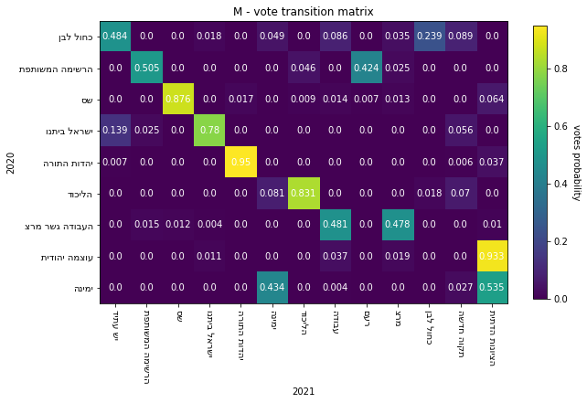

[interactive chart not shown]

```python
Nab, Nbb = process_matrix(merged_ballots_for_f)
ab = Nab.rename(columns=parties_dict_2020_for_f, inplace= False)
bb = Nbb.rename(columns=parties_dict_2021_for_f, inplace= False)

parties_2020, parties_2021 = ab.columns, bb.columns

#creating matrix of votes
Nab, Nbb = Nab.values, Nbb.values

# Calculating M
M = np.linalg.pinv(Nab.T @ Nab) @Nab.T @ Nbb
M = pd.DataFrame(np.where(M < 0.005, 0, M))
M = M.div(M.sum(axis = 1), 0)
corr_heat_map(np.array(M), parties_2021, parties_2020)

#creating table of votes
index_row = list(range(0, 10))
dict_row = dict(zip(index_row, parties_2020))
M_new = M
M_new.columns = parties_2021
M_new.rename(dict_row, inplace= True)
gimel_20_to_21 = pd.DataFrame(M_new.iloc[4,:],parties_2021) # table
gimel_20_to_21 = gimel_20_to_21.sort_values('יהדות התורה', ascending=False)
fig_gimel =go.Figure(data=[go.Table(header=dict(values=["votes in abs. number","percentage of ditching","ditching to party:"],fill_color='gray', line_color='black'),
                 cells=dict(values=[[round(k*df_2020_ballot.loc[:,'יהדות התורה'].sum()) for k in gimel_20_to_21.iloc[0:4,0]],[str(round(i*100,2))+"%" for i in gimel_20_to_21.iloc[0:4,0]],
                                    [name for name in gimel_20_to_21.index[0:4]]],fill_color='white', line_color='black'))])
fig_gimel.update_layout(width=800, height=300, title="The transfer of votes from Yahadut Hatora : 2020 to 2021 elections.",title_x = 0.5, title_y = 0.78 )
```

According to the heating map we have made, you can see which parties have passed from the previous elections to the recent ones. In the table we summarized for which parties the votes went from 2020 to 2021.

[figure not shown]

In this section, we estimated the percentage of votes that passed from the voters of the "Yahadut Hatora" Party in the 2020 elections to the parties in the elections 2021. In order to address relevant voice transitions we filtered the voice transitions that are below 0.5% of votes. Note that because the majority of votes went to the Yahadut Hatora Party also in 2021, while 3.72% of "Yahadut Hatora" voters in 2020 did not Vote in the 2021 election and vote for "הציונות הדתית" this makes sense, since there was pressure to vote for this party, for fear that they will not pass the blocking percentage.

Second in line is a vote for "Yesh Atid" which is a bit surprising considering that they do not belong to the same political camp and even sworn opponents in the Knesset.This result is affected by the fact that we did not address this section without voters, this will be resolved in the next section.

*In conclusion, the voters of the Torah Judaism Party are relatively sticking to voting for the party. When there is a transition of votes from the Yahadut Hatora Party, They are moving to to "הציונות הדתית" parte, a party with a ideologically similar vision and therefore there is a danger of losing voters to such a party and similar to it.*

### *G. Introduce the transition of the new votes to the party, i.e. voters who moved to the party in the election 2021 from other parties in the previous elections (including those who did not vote in them) from which parties Did the most voters go to your party:*

```python
### now we need the column2020 of gimel which is the row of gimel in transpose matrix
gimel_21_from_20 = pd.DataFrame(M_new.T.iloc[4,:],parties_2020)
gimel_21_from_20 = gimel_21_from_20.sort_values(gimel_21_from_20.columns[0], ascending=False)

value_list = [round(i) for i in [gimel_21_from_20.iloc[0,0]*df_2020_ballot.loc[:,'יהדות התורה'].sum(),
                                 gimel_21_from_20.iloc[1,0]*df_2020_ballot.loc[:,'שס'].sum()]]
tot_sum = value_list[0] + value_list[1]
```

```python
### table
fig_gimel2 =go.Figure(data=[go.Table(header=dict(values=["% from total votes of 2021 Yahadut Hatora","votes in abs. number",
                                                         "percentage of ditching \n (in correct party)","ditching from party..."],fill_color='gray', line_color='black'),
                 cells=dict(values=[[str(round(v/tot_sum*100,2)) +"%" for v in value_list],value_list,[str(round(i*100,2))+"%" for i in gimel_21_from_20.iloc[0:2,0]],
                                    [name for name in gimel_21_from_20.index[0:2]]],fill_color='white', line_color='black'))])
fig_gimel2.update_layout(width=800, height=300 ,title="The transfer of votes from other parties to Yahadut Hatora : 2021 from 2020 elections",title_x=0.5, title_y = 0.78 )
```

[interactive chart not shown]

[figure not shown]

It can be seen that Shas voters channged their minds in favor of Torah Judaism in the last elections. This makes a lot of sense, since the parties have broadly similar identities.

In this section, we estimated the percentage of votes passed from voters of other parties to the Yahadut Hatora Party since the 2020 elections for the 2021 elections. It can be seen that the Yahadut Hatora Party received the majority of its votes (except for the party itself) from the party Shas in the transition from the 2020 election to the 2021. Election Note that it received 1.68% of Israel's votes.

*In conclusion, Yahadut Hatora has the potential to gain votes from parties from the political right bloc, especially from the extreme religious right.*

### *H. How do non-voters / clusters affect voice transitions? Which sagittal passages? Some Good predictions model the vote transitions for the party.*

*Note: According to the refinement of the question, there was confusion between what was required in sections F, G and H. These sections (H) were included the "non-voters" but were not included in section (F,G). Or zuk approved this replacement as it was included in section H (thus making it easier for us to change the sections - thank you). It may be noted that his questions were explained at length.*

Here we will perform identical calculations to the previous section, we will just enter the matter non-voters

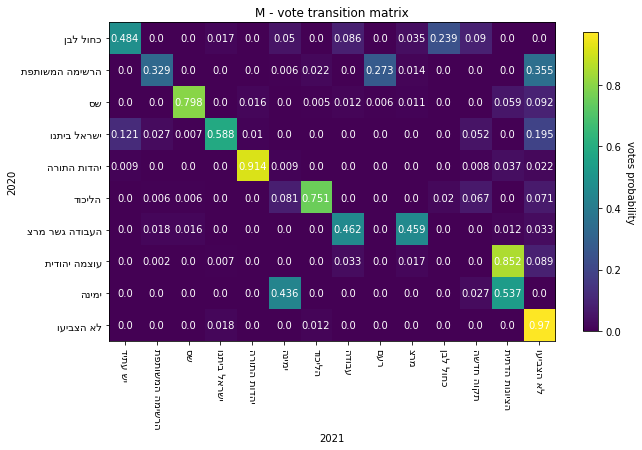

[interactive chart not shown]

```python
Nab_nv, Nbb_nv = process_matrix(merged_ballots_for_f, True)
ab_nv = Nab_nv.rename(columns=parties_dict_2020_for_f, inplace= False)
bb_nv = Nbb_nv.rename(columns=parties_dict_2021_for_f, inplace= False)

parties_2020_nv, parties_2021_nv = ab_nv.columns, bb_nv.columns

#creating matrix of votes
Nab_nv = Nab_nv.values
Nbb_nv = Nbb_nv.values

# Calculating M
M_nv = np.linalg.pinv(Nab_nv.T @ Nab_nv) @Nab_nv.T @ Nbb_nv
M_nv = pd.DataFrame(np.where(M_nv< 0.005, 0, M_nv))
M_nv = M_nv.div(M_nv.sum(axis = 1), 0)
corr_heat_map(np.array(M_nv), parties_2021_nv, parties_2020_nv)

#creating table of votes
index_row_nv = list(range(0, 11))
dict_row_nv = dict(zip(index_row, parties_2020_nv))
M_new_nv = M_nv
M_new_nv.columns = parties_2021_nv
M_new_nv.rename(dict_row_nv, inplace= True)
gimel_20_to_21_nv = pd.DataFrame(M_new_nv.iloc[4,:],parties_2021_nv) # table
gimel_20_to_21_nv = gimel_20_to_21_nv.sort_values('יהדות התורה', ascending=False)
fig_gimel =go.Figure(data=[go.Table(header=dict(values=["votes in abs. number","percentage of ditching","ditching to party:"],fill_color='gray', line_color='black'),
                 cells=dict(values=[[round(k*df_2020_ballot.loc[:,'יהדות התורה'].sum()) for k in gimel_20_to_21_nv.iloc[0:6,0]],[str(round(i*100,2))+"%" for i in gimel_20_to_21_nv.iloc[0:6,0]],
                                    [name for name in gimel_20_to_21_nv.index[0:6]]],fill_color='white', line_color='black'))])
fig_gimel.update_layout(width=800, height=500, title="The transfer of votes from Yahadut Hatora : 2020 to 2021 elections.",title_x = 0.5, title_y = 0.78 )
```

[figure not shown]

Let us note that when we introduced the parameter of non-voting, we received that these are the parties that passed to them the votes from the party from the elections of 2020 to 2021. This makes more sense due to the fact, that there have been more election campaigns in recent years and with less voting again, it makes more sense that there will be less movement from the party to the other parties due to the nature of the votes.

```python
### now we need the column2020 of gimel which is the row of gimel in transpose matrix
gimel_21_from_20_nv = pd.DataFrame(M_new_nv.T.iloc[4,:],parties_2020_nv)
gimel_21_from_20_nv = gimel_21_from_20_nv.sort_values(gimel_21_from_20_nv.columns[0], ascending=False)

value_list = [round(i) for i in [gimel_21_from_20_nv.iloc[0,0]*df_2020_ballot.loc[:,'יהדות התורה'].sum(),
                                 gimel_21_from_20_nv.iloc[1,0]*df_2020_ballot.loc[:,'שס'].sum(),
                                 gimel_21_from_20_nv.iloc[2,0]*df_2020_ballot.loc[:,'ישראל ביתנו'].sum()]]
tot_sum = value_list[0] + value_list[1] + value_list[2]
```

```python
### table
fig_gimel2 =go.Figure(data=[go.Table(header=dict(values=["% from total votes of 2021 Yahadut Hatora","votes in abs. number",
                                                         "percentage of ditching \n (in correct party)","ditching from party..."],fill_color='gray', line_color='black'),
                 cells=dict(values=[[str(round(v/tot_sum*100,2)) +"%" for v in value_list],value_list,[str(round(i*100,2))+"%" for i in gimel_21_from_20_nv.iloc[0:3,0]],
                                    [name for name in gimel_21_from_20_nv.index[0:3]]],fill_color='white', line_color='black'))])
fig_gimel2.update_layout(width=800, height=300 ,title="The transfer of votes from other parties to Yahadut Hatora :  2021 from 2020 elections",title_x=0.5, title_y = 0.78 )
```

[interactive chart not shown]

[figure not shown]

It should be noted, that when we compute the non-voters it is obtained that there were new votes, which transitioned from Israel Beitanu Party. This is surprising due to the nature of the background of parties voters from Israel Beitanu, since they hold opposing beliefs to Yahdut HaTorah Party. However, this can be explained by an understanding of how the voting percentages has influenced them.

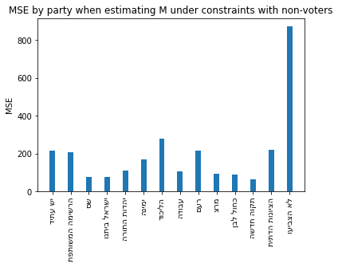

```python
M_nv = np.linalg.pinv(Nab_nv.T @ Nab_nv) @Nab_nv.T @ Nbb_nv
M_nv = np.where(M_nv< 0.005, 0, M_nv)

res = Nab_nv @ M_nv - Nbb_nv
mse = sum(np.power(res,2))/res.shape[0]

# bar-plot:

width = 0.3  # set column width
n = Nbb_nv.shape[1]  # number of parties
names = parties_2021_nv
rev_names = [name[::-1] for name in list(names)]

fig, ax = plt.subplots()  # plt.subplots()

mse_bar = ax.bar(np.arange(n), np.array(mse), width)

ax.set_ylabel('MSE')
ax.set_title('MSE by party when estimating M under constraints with non-voters')
ax.set_xticks(np.arange(n))
ax.set_xticklabels(rev_names,rotation=90)
plt.show()
```

Perhaps it can be said that their base is more solid, i.e. less fluctuations. So too in Torah Judaism, their base is very conservative and orthodox, and vote for them again and again.

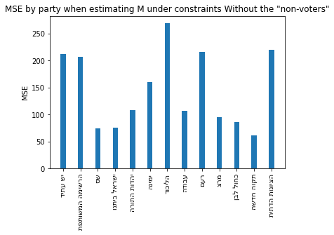

```python
M = np.linalg.pinv(Nab.T @ Nab) @Nab.T @ Nbb
M = np.where(M< 0.005, 0, M)

res = Nab @ M - Nbb
mse = sum(np.power(res,2))/res.shape[0]

# bar-plot:

width = 0.3  # set column width
n = Nbb.shape[1]  # number of parties
names = parties_2021
rev_names = [name[::-1] for name in list(names)]

fig, ax = plt.subplots()  # plt.subplots()

mse_bar = ax.bar(np.arange(n), np.array(mse), width)

ax.set_ylabel('MSE')
ax.set_title('MSE by party when estimating M under constraints Without the "non-voters"')
ax.set_xticks(np.arange(n))
ax.set_xticklabels(rev_names,rotation=90)
plt.show()
```

It can be noted that for the "Yahadut Hatora" party there was no change when we did not include the non-voters in the transition matrix, since the party's turnout is very high so that they are not affected by the non-voters column.

*In conclusion, "non-voters" column not improves the estimation of the voting to "Yahadut Hatora" party.*

### *i. Show polls that look suspicious to you, and explain how they might affect party voting.*

We are interested in checking whether there are any ballots suspected of bias in the Torah Judaism Party. The first way to do this is to check if there are ballots in a particular city whose voting patterns are significantly different from the voting patterns in the entire city. For this purpose will find the 10 ballots where the square distance between the percentage of votes for Torah Judaism in the ballot and the average percentage of votes in the city is the highest.

```python
data_type = "ballot"

if run_in_colab:
    if data_type == "city":
      df_2021_raw = pd.read_csv(io.BytesIO(uploaded['votes per city 2021.csv']),  encoding = 'iso-8859-8', index_col='שם ישוב')
      df_2020_raw = pd.read_csv(io.BytesIO(uploaded['votes per city 2020.csv']),  encoding = 'iso-8859-8', index_col='שם ישוב')
    else:
      df_2021_raw = pd.read_csv(io.BytesIO(uploaded['votes per ballot 2021.csv']),  encoding = 'iso-8859-8', index_col='שם ישוב')
      df_2020_raw = pd.read_csv(io.BytesIO(uploaded['votes per ballot 2020.csv']),  encoding = 'iso-8859-8', index_col='שם ישוב')

else:  # read local file
    if data_type == "ballot":
        df_2021_raw = pd.read_csv(data_path + 'votes per ballot 2021.csv',  encoding = 'iso-8859-8', index_col='שם ישוב')
        df_2020_raw = pd.read_csv(data_path + 'votes per ballot 2020.csv',  encoding = 'iso-8859-8', index_col='שם ישוב')
    else:
        df_2021_raw = pd.read_csv(data_path + 'votes per city 2021.csv',  encoding = 'iso-8859-8', index_col='שם ישוב')
        df_2020_raw = pd.read_csv(data_path + 'votes per city 2020.csv',  encoding = 'iso-8859-8', index_col='שם ישוב')

if data_type == "ballot":
    # preprocessing of ballot
    # convert columns with the parties' names

    df_2021_raw.rename(columns=parties_dict_2021, inplace=True)
    df_2021_raw = df_2021_raw[df_2021_raw.columns[:-1]]
    df_2021 = df_2021_raw.drop('סמל ועדה', axis=1) # new column added in Sep 2019
    df_2021 = df_2021[df_2021.columns[9:]] # removing "metadata" columns

    df_2020_raw.rename(columns=parties_dict_2020, inplace=True)
    df_2020_raw = df_2020_raw[df_2020_raw.columns[:-1]]
    df_2020 = df_2020_raw.drop('סמל ועדה', axis=1) # new column added in Sep 2019
    df_2020 = df_2020[df_2020.columns[9:]] # removing "metadata" columns
else:
    # preprocessing of cities
    df_2021_raw.rename(columns=parties_dict_2021, inplace=True)
    df_2021_raw = df_2021_raw[df_2021_raw.columns[:-1]]
    df_2021 = df_2021_raw.drop('סמל ועדה', axis=1) # new column added in Sep 2019
    df_2021 = df_2021[df_2021.columns[5:]] # removing "metadata" columns

    df_2020_raw.rename(columns=parties_dict_2020, inplace=True)
    df_2020_raw = df_2020_raw[df_2020_raw.columns[:-1]]
    df_2020 = df_2020_raw.drop('סמל ועדה', axis=1) # new column added in Sep 2019
    df_2020 = df_2020[df_2020.columns[5:]] # removing "metadata" columns
# Dataset is now stored in a Pandas Dataframe

total_votes = parties_votes_percents(df_2021, 0.035)  # total votes for each party
names = total_votes.keys() # largest parties

total_votes_2020 = parties_votes_percents(df_2020, 0.035)  # total votes for each party
names_2020 = total_votes_2020.keys().tolist() # largest parties
names_2020.append('עוצמה יהודית')

df_2020_ballot = df_2020_raw.reset_index()
df_2021_ballot = df_2021_raw.reset_index()
ballot_match = df_2020_ballot.set_index(['קלפי', 'סמל ישוב','שם ישוב']).join(df_2021_ballot.set_index(['קלפי', 'סמל ישוב','שם ישוב']), lsuffix = '-2020' , how='inner')

# Adapting data so we will have only ballots that were in 2020 and in 2021:
ballot_2021 = ballot_match[ballot_match.columns[len(df_2020_ballot.columns)-3:]]
ballot_2020 = ballot_match[ballot_match.columns[0:len(df_2020_ballot.columns)-3]]
ballot_2020.columns = df_2020_ballot.set_index(['קלפי', 'סמל ישוב','שם ישוב']).columns

#Now we will merge the parties that are togeter in 2020 but were seperated in 2021:
parties_2020 = ballot_2020.copy()

#splitting to עבודה and מרצ
parties_2020['מרצ'] = 0.5 *parties_2020['עבודה גשר מרצ']
parties_2020['עבודה'] = 0.5 *parties_2020['עבודה גשר מרצ']
parties_2020.drop('עבודה גשר מרצ', axis=1)
#splitting to רעם and המשותפת
parties_2020['רעם'] = 0.4 *parties_2020['הרשימה המשותפת']
parties_2020['הרשימה המשותפת'] = 0.6 *parties_2020['הרשימה המשותפת']
#splitting to תקוה חדשה and הליכוד
parties_2020['תקוה חדשה'] = 0.167 *parties_2020['הליכוד']
parties_2020['הליכוד'] = 0.833 *parties_2020['הליכוד']
#splitting to כחול לבן and יש עתיד
parties_2020['יש עתיד'] = 0.667 *parties_2020['כחול לבן']
parties_2020['כחול לבן'] = 0.333 *parties_2020['כחול לבן']
#splitting to ימינה and הציונות הדתית
parties_2020['הציונות הדתית'] = 0.4*parties_2020['ימינה']
parties_2020['ימינה'] = 0.6 *parties_2020['ימינה']
parties_2020['הציונות הדתית'] = parties_2020['הציונות הדתית']  + parties_2020['עוצמה יהודית']
parties_2020.drop('עוצמה יהודית', axis = 1)

#only perties + normalization:
parties_2020 = parties_2020[parties_2020.columns[8:]]
parties_2020 = parties_2020.div(parties_2020.sum(axis = 1), axis = 0)

#only perties + normalization:
parties_2021 = ballot_2021.copy()

parties_2021 = parties_2021[parties_2021.columns[8:]]
parties_2021 = parties_2021.div(parties_2021.sum(axis = 1), axis= 0)

small_cities = ballot_2021.groupby('שם ישוב').sum()
small_cities = small_cities.iloc[np.where(small_cities['בזב']<= 50000)]
```

```python
yh_2021 = parties_2021['יהדות התורה'].to_frame()
yh_2020 =  parties_2020['יהדות התורה'].to_frame()

def diff_calc(df):
  mean_city = df.mean(axis=0)
  diff = df - mean_city
  return diff

parties_2021_small = yh_2021.iloc[np.where(yh_2021.index.get_level_values(2).isin(small_cities.index))]
top_10_2021 = ((parties_2021_small.groupby('שם ישוב').apply(lambda x: diff_calc(x)))**2).sum(axis=1).nlargest(10)
```

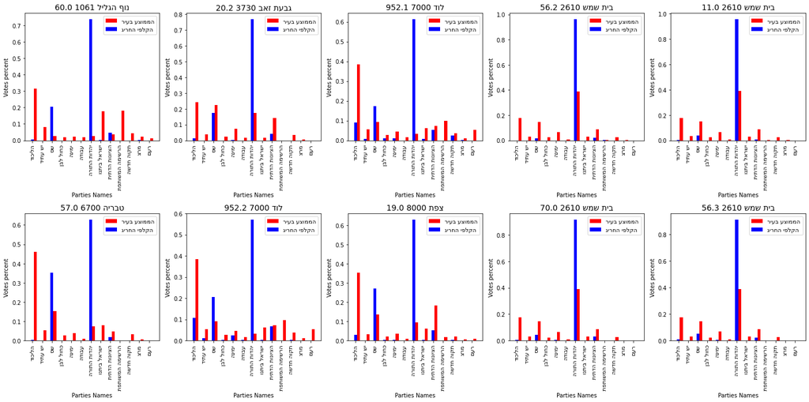

```python
def bar_plots(parties_2020, parties_2021, tops, names, seif_b = False, Y_2021 = False):
  fig, ax = plt.subplots(2, 5, figsize=(20,10))
  width = 0.3  # set column width

  votes_2020 = parties_2020[names].loc[tops]  # total votes for each party
  if seif_b:
    wanted_cities = tops.get_level_values(2)
    votes_2021 = parties_2020.reset_index().set_index('שם ישוב').loc[wanted_cities[0]].groupby('שם ישוב').mean()[names] # normalize by number of ballots in city

    for city in wanted_cities[1:]:
      votes_2021 = votes_2021.append(parties_2020.reset_index().set_index('שם ישוב').loc[city].groupby('שם ישוב').mean()[names] ) # need to normalize

  else:
    votes_2021 = parties_2021[names].loc[tops]  # do not normalize

  rev_names = [name[::-1] for name in list(names)]
  n = len(names)

  for ballot in range(10):
    title_top = str(tops[ballot][0]) +" " + str(tops[ballot][1]) + " " +tops[ballot][2][::-1]
    bar_2020 = ax[ballot//5, ballot%5].bar(np.arange(n), list(votes_2020.iloc[ballot]), width, color='b')
    bar_2021 = ax[ballot//5, ballot%5].bar(np.arange(n)+width, list(votes_2021.iloc[ballot]), width, color='r')
    ax[ballot//5, ballot%5].set_title(title_top, fontsize=14)

    ax[ballot//5, ballot%5].set_xticks(np.arange(n))
    ax[ballot//5, ballot%5].set_xticklabels(rev_names, rotation=90)
    if seif_b:
      ax[ballot//5, ballot%5].legend((bar_2021[0], bar_2020[0]),('ריעב עצוממה','גירחה יפלקה'))
    else:
      ax[ballot//5, ballot%5].legend((bar_2021[0], bar_2020[0]),('2021 תוריחב','2020 תוריחב'))
  for ax in ax.flat:
    ax.set_ylabel('Votes percent')
    ax.set_xlabel('Parties Names')

  plt.tight_layout()
  plt.show()

bar_plots(parties_2021, parties_2021, top_10_2021.index, names, True, True)  # Show ballots found in (b)
```

We see that the 10 polling stations that we presented above the turnout in Torah Judaism is very high compared to the average vote in the city. Let us note, that in none of the polling stations did we find the opposite relationship - that the average vote in the city for Torah Judaism is higher than the vote in a particular polling station.

Although there is an unusual vote for the Torah Judaism Party in the above 10 polling stations, we believe that this does not indicate a suspicion of forgery at those polling stations. We know that ultra-Orthodox society is characterized by the fact that the ultra-Orthodox live in areas close to each other and often these are the neighborhoods where the vast majority of the residents are only ultra-Orthodox. Thus, the exceptional polling stations are probably polling stations located in distinctly ultra-Orthodox neighborhoods (and in cities where the ultra-Orthodox population is not necessarily exceptionally high) and therefore in these polling stations the vote for the Torah Judaism Party is significantly higher than the city average.

**Another way for finding suspicious polls is to compare the results of the 2020 election to the 2021 results.**

We will examine the polling stations for which the square distance in the percentage of votes for the Torah Judaism Party is the highest. Let us note that in this way the characteristic of the party's ultra-Orthodox supporters who tend to live in close proximity to each other will not be affected since we look at the same ballot box in different election campaigns.

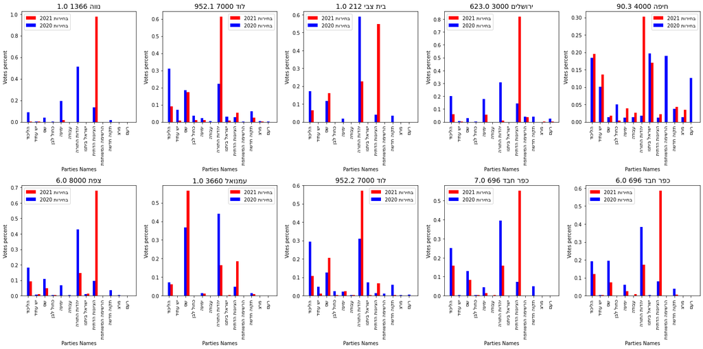

```python
a= ((parties_2020['יהדות התורה']-parties_2021['יהדות התורה'])**2).nlargest(10)
bar_plots(parties_2020, parties_2021, a.index, names)
```

There are sometimes suspicious polls, that are worth for examination: Since we have seen that there was a transition from the Yahudut HaTorah Party to the Ziunot HaDatit Party, it is possible that the ballots in Jerusalem, Beit Zvi, Kfar Chabad, Emanuel and Safed are less suspicious compared to the rest. It might have happened because ultra-Orthodox-nationalist who did not want to vote for the United Right Party in the 2020 elections (since it is a less religious party than the "Religious Zionism" party that separated from it) but following the split in the Right Party they decided to vote for Ziunot HaDatit.

At the other ballots, the ballot box caught our eye in Haifa, where there was a great transition between the Arab parties in the 2020 elections and the Yahudut HaTorah Party. In our opinion, this is the most suspicious polling station of all the polling stations that our survey raised, since these are parties that appeal too significantly different populations.

**Final Conclusion:**

We have conducted a statistical analysis of the Yahadut HaTora in the last election campaigns: between 2020 and 2021 years. In the analysis, we characterized the party's voters in the 2 election campaigns by division voters into socio-economic level, right or left beliefs also taking into account in which localities and polling stations the party was stronger and which was weaker and we had checked the suspicious polling stations as well.

```python
%%shell
jupyter nbconvert --to html /content/final.ipynb
```

```
[NbConvertApp] Converting notebook /content/final.ipynb to html
[NbConvertApp] Writing 1391450 bytes to /content/final.html
```